# People-based Machine Learning for a Housing Subsidy Program

Chi Zhang (Partner:Zhijie Zhou)

2020/10/30

## 1. Background

To improve urban environment and house value of neighborhood, Emil City decides supply a 5,000 dollar home repair tax credit to each qualified houseowner. Though the Department of Housing and Community Development (HCD) tries to proactively reach out to eligible homeowners ever year, only 11% of eligible homeowners take the credit based on the previous experience. Therefore, a Logistic regression model is built based on the prior sample records to explore efficient factors that increase the conversion rate of potential houseowners. At the end, cost-benefit analysis is conducted to predict the social externality that could be brought by this house improvement policy.

```r
knitr::opts_chunk$set(echo = TRUE, warning = FALSE, message = FALSE, fig.width=12, fig.height=9)

options(scipen=10000000)

library(tidyverse)
library(kableExtra)
library(caret)
library(knitr)
library(pscl)
library(plotROC)
library(pROC)
library(lubridate)

palette5 <- c("#ff9f1c","#ffbf69","#cbf3f0","#2ec4b6")
palette4 <- c("#981FAC","#FF006A","#FE4C35","#FE9900")
palette2 <- c("#2ec4b6","#ff9f1c")

plotTheme <- function(base_size = 12) {
  theme(
    text = element_text( color = "black"),
    plot.title = element_text(size = 14,colour = "black"),
    plot.subtitle = element_text(face="italic"),
    plot.caption = element_text(hjust=0),
    axis.ticks = element_blank(),
    panel.background = element_blank(),
    panel.grid.major = element_line("grey80", size = 0.1),
    panel.grid.minor = element_blank(),
    panel.border = element_rect(colour = "black", fill=NA, size=2),
    strip.background = element_rect(fill = "grey80", color = "white"),
    strip.text = element_text(size=12),
    axis.title = element_text(size=12),
    axis.text = element_text(size=10),
    plot.background = element_blank(),
    legend.background = element_blank(),
    legend.title = element_text(colour = "black", face = "italic"),
    legend.text = element_text(colour = "black", face = "italic"),
    strip.text.x = element_text(size = 14)
  )
}


houSubsidy <- read.csv("F:\\MUSA\\MUSA-505\\assignment4\\data\\housingSubsidy.csv")

houSubsidy <-
houSubsidy %>%
  dplyr::rename(Accept=y)
```

## 2. Data Exploration

Statistical analysis of differences is processed to explore the characteristics of the houseowners who take or didn’t take the credit.

### 2.1 Continuous Features

Following bar plots demonstrate feature associations with the likelihood of taking the credit. The mean value of features are count grouped by the houseowners’ choice. As we can see, number of contacts during the campaign(campaign), inflation rate, number of days that passed by after the client was last contacted(Pdays), number of contacts performed before this campaign(Previous) and umemployment rate are more likley to influence houseowners’ responds.

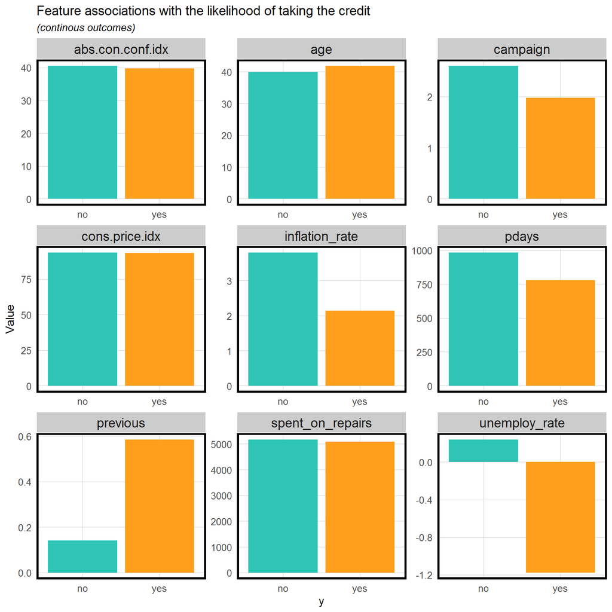

```r
houSubsidy <-
houSubsidy %>%
  mutate(abs.con.conf.idx= abs(cons.conf.idx))%>%
  mutate(pdays.cat = case_when(pdays < 999  ~ "Previously Contacted",
                             pdays >= 999  ~ "Never Contacted"),
         unemploy_rate.cat = case_when(unemploy_rate >= 0  ~ "Increase",
                             TRUE ~ "Decrease"),
         inflation_rate.cat = case_when(inflation_rate >= 3  ~ "Y",
                             TRUE ~ "N"),
         age.cat = case_when(age < 30 ~ "YOUNG",
                              age >= 30 & age < 45 ~ "MIDDLE-YOUNG",
                              age >= 45 & age < 65 ~ "MIDDLE",
                              age >= 65 ~ "SENIOR"),
         edu.cat = case_when(education == 'basic.4y' | education == 'basic.6y' | education == 'basic.9y' ~ "BASIC",
                              education == 'high.school' ~ "HIGHSCHOOL",
                              education == 'professional.course' | education == 'university.degree' ~ "HIGHER",
                              TRUE ~ 'OTHER'))



houSubsidy %>%
  dplyr::select(Accept,age, campaign, pdays, previous, unemploy_rate, cons.price.idx, abs.con.conf.idx, inflation_rate, spent_on_repairs) %>%
  gather(Variable, value, -Accept) %>%
    ggplot(aes(Accept, value, fill=Accept)) +
      geom_bar(position = "dodge", stat = "summary") +
      facet_wrap(~Variable, scales = "free") +
      scale_fill_manual(values = palette2) +
      labs(x="y", y="Value",
           title = "Feature associations with the likelihood of taking the credit",
           subtitle = "(continous outcomes)") +
      plotTheme()+
      theme(legend.position = "none")
```

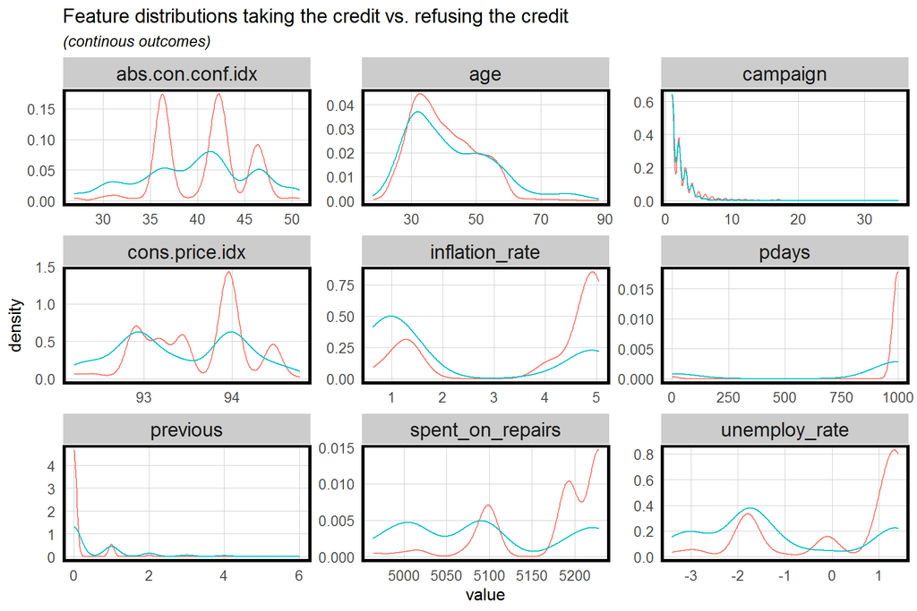

```r
houSubsidy %>%
    dplyr::select(Accept,age, campaign, pdays, previous, unemploy_rate, cons.price.idx, abs.con.conf.idx, inflation_rate, spent_on_repairs) %>%
    gather(Variable, value, -Accept) %>%
    ggplot() +
    geom_density(aes(value, color= Accept), fill = "transparent") +
    facet_wrap(~Variable, scales = "free") +
    scale_fill_manual(values = palette2) +
    labs(title = "Feature distributions taking the credit vs. refusing the credit",
         subtitle = "(continous outcomes)") +
    plotTheme()+
    theme(legend.position = "none")
```

### 2.2 Category Features

Below are series of plots demonstrates category feature associations with the likelihood of taking the credit. It calculates the total number of houseowners reported as ‘Yes’ or ‘No’ for a given feature. It is noticed that not only the count of ‘Yes’, but also the share of ‘Yes’ should be focused. For example, it seems that there are most number of houseowners took the credit in May. But we are not able to draw a conclusion that houseowners are more likely accept the credit in May than in other months. One explanation is that the great total number of contacts leads to the large count of ‘Yes’. In fact, the share of ‘Yes’ in June is greater than that in May.

Through a skim of following tables, count of taking credit on different day of week is evenly distributed, which could be considered to drop in the final model.

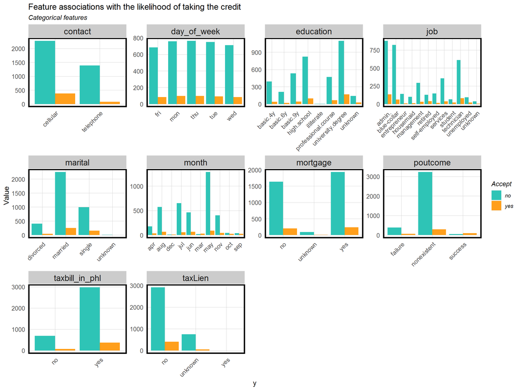

```r
houSubsidy %>%
    dplyr::select(Accept, job, marital, education, taxLien, mortgage, taxbill_in_phl, contact, month, day_of_week, poutcome ) %>%
    gather(Variable, value, -Accept) %>%
    count(Variable, value, Accept) %>%
      ggplot(., aes(value, n, fill = Accept)) +
        geom_bar(position = "dodge", stat="identity") +
        facet_wrap(~Variable, scales="free") +
        scale_fill_manual(values = palette2) +
        labs(x="y", y="Value",
             title = "Feature associations with the likelihood of taking the credit",
             subtitle = "Categorical features") +
        plotTheme()+
        theme(axis.text.x = element_text(angle = 45, hjust = 1))
```

## 3. Logistic regression

### 3.1 Training/Testing sets

Logistic regression predicts the probability an observation is part of a group, like ‘take the credit’ or ‘refuse the credit’, conditional on the features of the model.

We partition our data into a 65/35 training and test set (`p = 0.65`) and call them sets `houSubsidyTrain` and `houSubsidyTest`.

```r
set.seed(6366)
trainIndex <- createDataPartition(houSubsidy$y_numeric, p = .65,
                                  y = paste(houSubsidy$edu.cat,houSubsidy$age.cat,houSubsidy$umemploy_rate.cat,
                                            houSubsidy$inflation_rate.cat,houSubsidy$pdays.cat),
                                  list = FALSE,
                                  times = 1)
houSubsidyTrain <- houSubsidy[ trainIndex,]
houSubsidyTest  <- houSubsidy[-trainIndex,]
```

### 3.2 Raw Model

All predictors from sample records are included in the raw model. The regression summary indicates that contact telephone, number of days that passed by after the client was last contacted(Pdays), month and CPI significantly correlate with houseowners’ choice.

```r
houSubsidyModel_all <- glm(y_numeric ~ .,
                  data=houSubsidyTrain %>%
                    dplyr::select(-cons.conf.idx, -X, -Accept, -pdays.cat, -age.cat, -unemploy_rate.cat,-taxLien,
                                  -inflation_rate.cat,-edu.cat),
                  family="binomial" (link="logit"))

summary(houSubsidyModel)
```

[output not shown]

[output cut: 10 more lines]

[output not shown]

```r
testProbs_all <- data.frame(Outcome = as.factor(houSubsidyTest$y_numeric),
                        Probs = predict(houSubsidyModel_all, houSubsidyTest, type= "response"))

testProbs_all <-
  testProbs_all %>%
  mutate(predOutcome  = as.factor(ifelse(testProbs_all$Probs > 0.5 , 1, 0)))

caret::confusionMatrix(testProbs_all$predOutcome, testProbs_all$Outcome,
                       positive = "1")
```

```
## Confusion Matrix and Statistics
##
##           Reference
## Prediction    0    1
##          0 1249  113
##          1   29   30
##
##                Accuracy : 0.9001
##                  95% CI : (0.8833, 0.9152)
##     No Information Rate : 0.8994
##     P-Value [Acc > NIR] : 0.4871
##
##                   Kappa : 0.2531
##
##  Mcnemar's Test P-Value : 0.000000000003279
##
##             Sensitivity : 0.20979
##             Specificity : 0.97731
##          Pos Pred Value : 0.50847
##          Neg Pred Value : 0.91703
##              Prevalence : 0.10063
##          Detection Rate : 0.02111
##    Detection Prevalence : 0.04152
##       Balanced Accuracy : 0.59355
##
##        'Positive' Class : 1
##
```

### 3.3 Feature Engineered Model

To raise the sensitivity of raw model, following engineering works are processed:

- transform continous features to category features, inlcuding ‘age’, ‘unemploy_rate’, ‘pdays’ and ‘inflation_rate’
- reclassify category features such as ‘education’
- drop some predictors without significant correlation, including ‘poutcome’, ‘taxLien’, ‘previous’, ‘mortgage’, ‘taxbill_in_phl’

```r
houSubsidyModel <- glm(y_numeric ~ .,
                  data=houSubsidyTrain %>%
                    dplyr::select(-cons.conf.idx, -X, -Accept, -poutcome, -age, -education, -taxLien, -previous, -mortgage, -unemploy_rate,
                                  -pdays, -inflation_rate, -taxbill_in_phl ),
                  family="binomial" (link="logit"))

summary(houSubsidyModel)
```

```
##
## Call:
## glm(formula = y_numeric ~ ., family = binomial(link = "logit"),
##     data = houSubsidyTrain %>% dplyr::select(-cons.conf.idx,
##         -X, -Accept, -poutcome, -age, -education, -taxLien, -previous,
##         -mortgage, -unemploy_rate, -pdays, -inflation_rate, -taxbill_in_phl))
##
## Deviance Residuals:
##     Min       1Q   Median       3Q      Max
## -2.0751  -0.4118  -0.3292  -0.2565   2.7734
##
## Coefficients:
##                                 Estimate Std. Error z value    Pr(>|z|)
## (Intercept)                   -61.787442 100.554309  -0.614     0.53891
## jobblue-collar                 -0.406633   0.272444  -1.493     0.13556
## jobentrepreneur                -0.695474   0.499663  -1.392     0.16396
## jobhousemaid                   -0.032623   0.440268  -0.074     0.94093
## jobmanagement                  -0.436373   0.306773  -1.422     0.15489
## jobretired                     -0.275667   0.380791  -0.724     0.46911
## jobself-employed               -0.702361   0.445918  -1.575     0.11524
## jobservices                    -0.296356   0.288689  -1.027     0.30463
## jobstudent                     -0.247497   0.438137  -0.565     0.57215
## jobtechnician                   0.027911   0.210127   0.133     0.89433
## jobunemployed                   0.268708   0.406493   0.661     0.50859
## jobunknown                     -0.613661   0.865979  -0.709     0.47855
## maritalmarried                  0.369840   0.254102   1.455     0.14554
## maritalsingle                   0.455052   0.284179   1.601     0.10931
## maritalunknown                  1.110402   1.116159   0.995     0.31981
## contacttelephone               -0.627794   0.250952  -2.502     0.01236 *
## monthaug                        0.043671   0.392448   0.111     0.91140
## monthdec                        0.270247   0.784227   0.345     0.73039
## monthjul                        0.366723   0.385677   0.951     0.34168
## monthjun                        0.753618   0.349592   2.156     0.03111 *
## monthmar                        1.648151   0.569749   2.893     0.00382 **
## monthmay                       -0.106416   0.318032  -0.335     0.73792
## monthnov                       -0.174058   0.599286  -0.290     0.77148
## monthoct                       -0.059736   0.574243  -0.104     0.91715
## monthsep                       -0.600430   0.561873  -1.069     0.28524
## day_of_weekmon                 -0.076985   0.213576  -0.360     0.71851
## day_of_weekthu                 -0.109320   0.216207  -0.506     0.61312
```

[output cut: 10 more lines]

```
## age.catSENIOR                  -0.181253   0.475381  -0.381     0.70300
## age.catYOUNG                   -0.414776   0.259781  -1.597     0.11035
## edu.catHIGHER                  -0.028979   0.227654  -0.127     0.89871
## edu.catHIGHSCHOOL              -0.056977   0.240460  -0.237     0.81269
## edu.catOTHER                    0.281323   0.346582   0.812     0.41696
## ---
## Signif. codes:  0 '***' 0.001 '**' 0.01 '*' 0.05 '.' 0.1 ' ' 1
##
## (Dispersion parameter for binomial family taken to be 1)
##
##     Null deviance: 1916.2  on 2697  degrees of freedom
## Residual deviance: 1489.8  on 2656  degrees of freedom
## AIC: 1573.8
##
## Number of Fisher Scoring iterations: 6
```

```r
testProbs <- data.frame(Outcome = as.factor(houSubsidyTest$y_numeric),
                        Probs = predict(houSubsidyModel, houSubsidyTest, type= "response"))

testProbs <-
  testProbs %>%
  mutate(predOutcome  = as.factor(ifelse(testProbs$Probs > 0.5 , 1, 0)))

caret::confusionMatrix(testProbs$predOutcome, testProbs$Outcome,
                       positive = "1")
```

```
## Confusion Matrix and Statistics
##
##           Reference
## Prediction    0    1
##          0 1255  109
##          1   23   34
##
##                Accuracy : 0.9071
##                  95% CI : (0.8908, 0.9217)
##     No Information Rate : 0.8994
##     P-Value [Acc > NIR] : 0.1777
##
##                   Kappa : 0.2998
##
##  Mcnemar's Test P-Value : 0.0000000000001379
##
##             Sensitivity : 0.23776
##             Specificity : 0.98200
##          Pos Pred Value : 0.59649
##          Neg Pred Value : 0.92009
##              Prevalence : 0.10063
##          Detection Rate : 0.02393
##    Detection Prevalence : 0.04011
##       Balanced Accuracy : 0.60988
##
##        'Positive' Class : 1
##
```

Plot below shows the distribution of predicted probabilities for ‘take the credit’ and ‘refuse the credit’, recorded as 1 and 0, respectively.

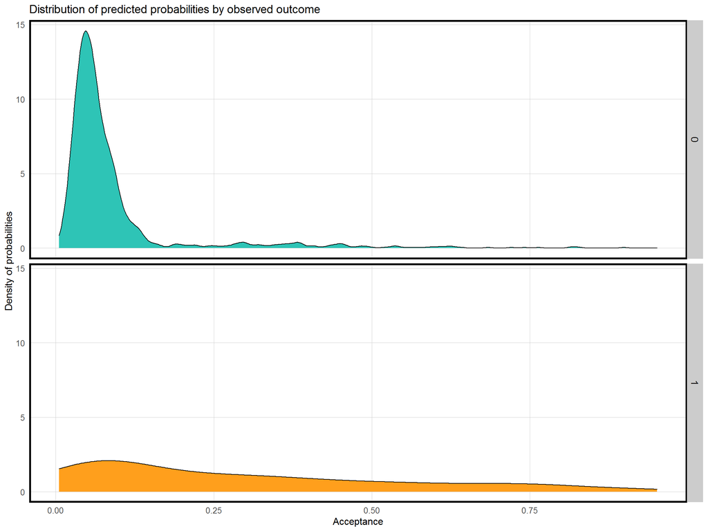

```r
ggplot(testProbs, aes(x = Probs, fill = as.factor(Outcome))) +
  geom_density() +
  facet_grid(Outcome ~ .) +
  scale_fill_manual(values = palette2) +
  plotTheme()+
  labs(x = "Acceptance", y = "Density of probabilities",
       title = "Distribution of predicted probabilities by observed outcome") +
  theme(strip.text.x = element_text(size = 18),
        legend.position = "none")
```

## 4. Cross validation

### 4.1 Raw Model

```r
ctrl <- trainControl(method = "cv", number = 100, classProbs=TRUE, summaryFunction=twoClassSummary)

cvFit_all <- train(Accept ~ .,
                  data=houSubsidy %>%
                    dplyr::select(-cons.conf.idx, -X, -y_numeric, -pdays.cat, -age.cat, -unemploy_rate.cat, -taxLien,
                                  -inflation_rate.cat, -edu.cat),
                method="glm", family="binomial",
                metric="ROC", trControl = ctrl)

cvFit_all
```

```
## Generalized Linear Model
##
## 4119 samples
##   18 predictor
##    2 classes: 'no', 'yes'
##
## No pre-processing
## Resampling: Cross-Validated (100 fold)
## Summary of sample sizes: 4078, 4077, 4078, 4077, 4078, 4079, ...
## Resampling results:
##
##   ROC        Sens       Spec
##   0.7693262  0.9812087  0.2215
```

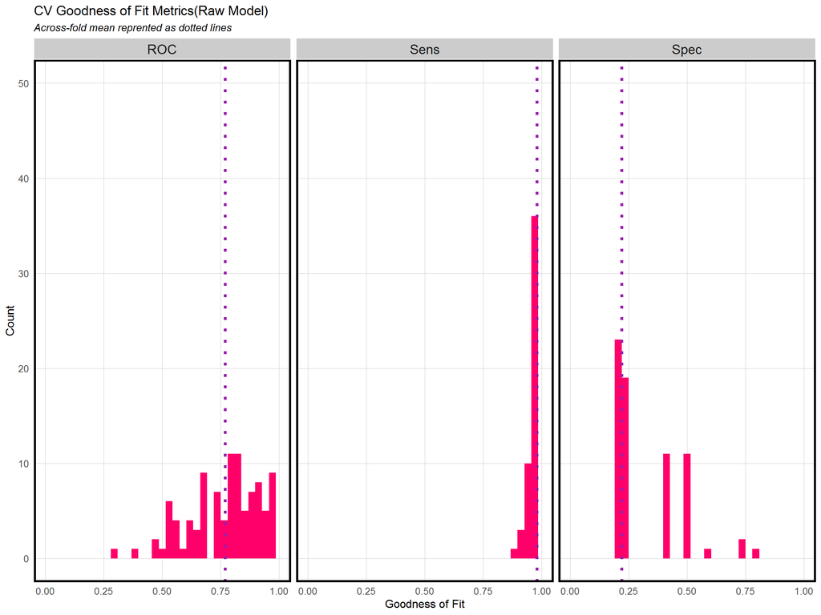

```r
dplyr::select(cvFit_all$resample, -Resample) %>%
  gather(metric, value) %>%
  left_join(gather(cvFit_all$results[2:4], metric, mean)) %>%
  ggplot(aes(value)) +
    geom_histogram(bins=35, fill = "#FF006A") +
    facet_wrap(~metric) +
    geom_vline(aes(xintercept = mean), colour = "#981FAC", linetype = 3, size = 1.5) +
    scale_x_continuous(limits = c(0, 1)) +
    plotTheme()+
    labs(x="Goodness of Fit", y="Count", title="CV Goodness of Fit Metrics(Raw Model)",
         subtitle = "Across-fold mean reprented as dotted lines")
```

### 4.2 Engineered Model

```r
cvFit <- train(Accept ~ .,
                  data=houSubsidy %>%
                    dplyr::select(-cons.conf.idx, -X, -y_numeric, -poutcome, -age, -education, -taxLien, -previous, -mortgage, -unemploy_rate,
                                  -pdays, -inflation_rate, -taxbill_in_phl),
                method="glm", family="binomial",
                metric="ROC", trControl = ctrl)

cvFit
```

```
## Generalized Linear Model
##
## 4119 samples
##   14 predictor
##    2 classes: 'no', 'yes'
##
## No pre-processing
## Resampling: Cross-Validated (100 fold)
## Summary of sample sizes: 4078, 4077, 4077, 4079, 4077, 4077, ...
## Resampling results:
##
##   ROC        Sens       Spec
##   0.7641126  0.9833934  0.2335
```

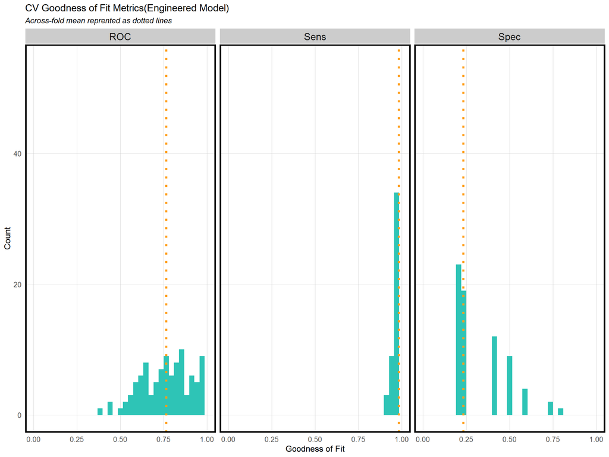

```r
dplyr::select(cvFit$resample, -Resample) %>%
  gather(metric, value) %>%
  left_join(gather(cvFit$results[2:4], metric, mean)) %>%
  ggplot(aes(value)) +
    geom_histogram(bins=35, fill = "#2ec4b6") +
    facet_wrap(~metric) +
    geom_vline(aes(xintercept = mean), colour = "#ff9f1c", linetype = 3, size = 1.5) +
    scale_x_continuous(limits = c(0, 1)) +
    plotTheme()+
    labs(x="Goodness of Fit", y="Count", title="CV Goodness of Fit Metrics(Engineered Model)",
         subtitle = "Across-fold mean reprented as dotted lines")
```

## 5. ROC Curve

The Receiver Operating Characteristic Curve(ROC Curve) visualizes trade-offs for two important confusion metrics, while also providing a single goodness of fit indicator. Below is a image from Wikipedia illustrates what’s a good ROC curve.

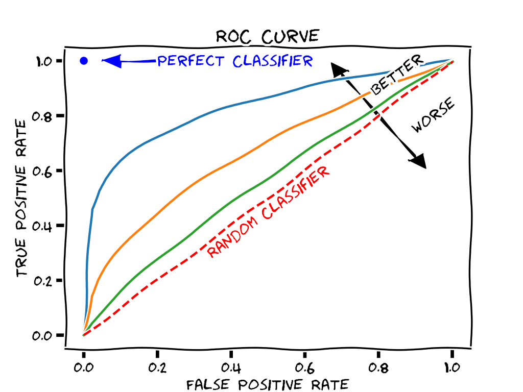

The ROC Curve of predicted results is positive. However, the curve is not quite smooth, which means there could be overfitting issue with regression model.

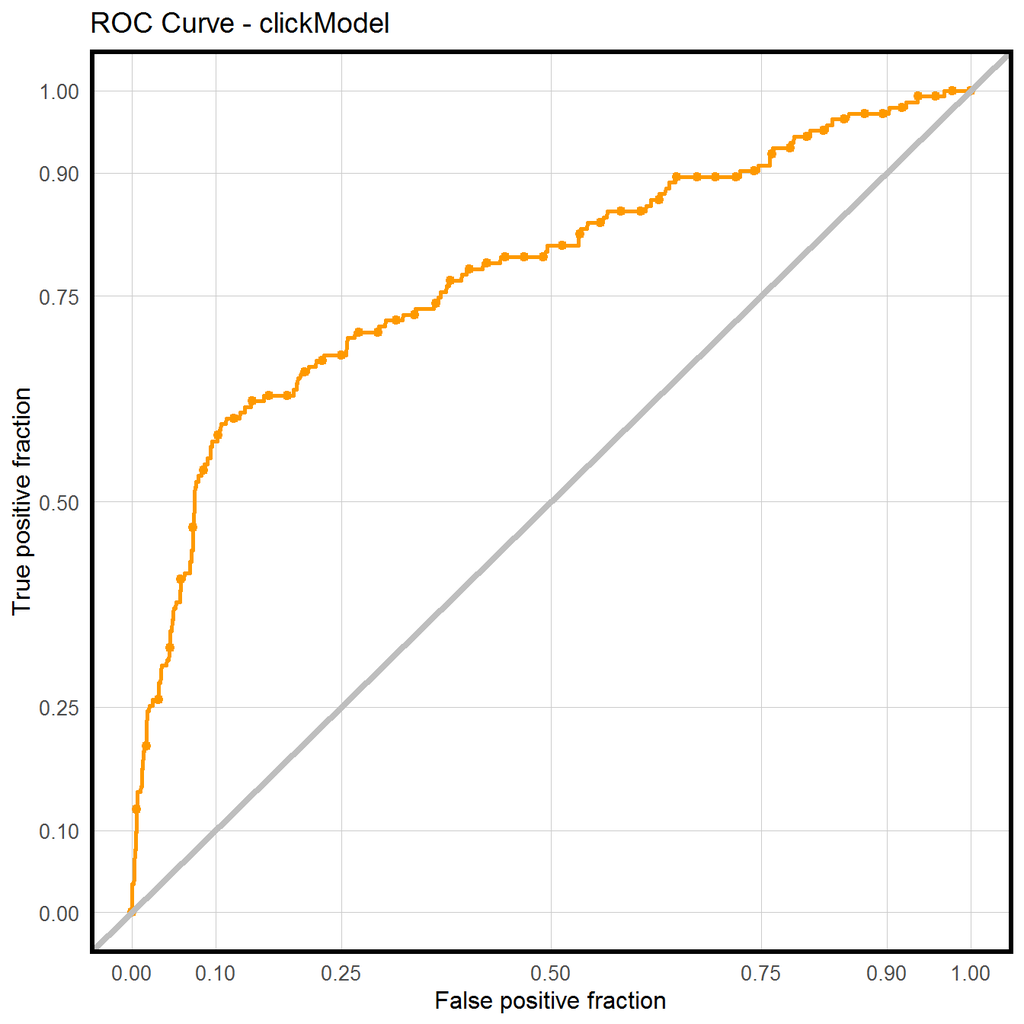

```r
ggplot(testProbs, aes(d = as.numeric(testProbs$Outcome), m = Probs)) +
  geom_roc(n.cuts = 50, labels = FALSE, colour = "#FE9900") +
  style_roc(theme = theme_grey) +
  geom_abline(slope = 1, intercept = 0, size = 1.5, color = 'grey') +
  plotTheme()+
  labs(title = "ROC Curve - clickModel")
```

AUC(Area Under the Curve) is another quick goodness of fit parameter. Usually the AUC is more closer to 1, the model is of better fitness. The AUC for our regression prediction is 0.7776.

```r
auc(testProbs$Outcome, testProbs$Probs)
```

```
## Area under the curve: 0.7776
```

## 6. Cost-Benefit Calculation

This has all been building to an examination of the model in the context of our ad campaign. Let’s set this up to estimate the revenues associated with using this model under the following scenario:

**True Positive**  
Predicted correctly homeowner would take the credit; allocated the marketing resources, and 25% took the credit.The revenue will be Count * 0.25*(66000-7850)$

**True Negative**  
Predicted correctly homeowner would not take the credit, no marketing resources were allocated, and no credit was allocated. The revenue for this scenario is 0

**False Positive**  
Predicted incorrectly homeowner would take the credit; allocated marketing resources; no credit allocated. The cost will be Count * (-2850)

**False Negative**  
Predicted that a homeowner would not take the credit but they did. These are likely homeowners who signed up for reasons unrelated to the marketing campaign. Thus, we ‘0 out’ this category, assuming the cost/benefit of this is $0.

```r
cost_benefit_table <-
  testProbs %>%
  count(predOutcome, Outcome) %>%
  summarize(True_Negative = sum(n[predOutcome==0 & Outcome==0]),
            True_Positive = sum(n[predOutcome==1 & Outcome==1]),
            False_Negative = sum(n[predOutcome==0 & Outcome==1]),
            False_Positive = sum(n[predOutcome==1 & Outcome==0])) %>%
  gather(Variable, Count) %>%
  mutate(Revenue =
           case_when(Variable == "True_Negative"  ~ Count * 0,
                     Variable == "True_Positive"  ~ Count * .25*(66000-7850),
                     Variable == "False_Negative" ~ Count * 0,
                     Variable == "False_Positive" ~ Count * (-2850))) %>%
  bind_cols(data.frame(Description = c(
    "Predicted correctly homeowner would not take the credit",
    "Predicted correctly homeowner would take the credit",
    "We predicted that a homeowner would not take the credit but they did",
    "Predicted incorrectly homeowner would take the credit")))

kable(cost_benefit_table) %>%
  kable_styling(font_size = 12, full_width = T,
                bootstrap_options = c("striped", "hover", "condensed")) %>%
  footnote(general_title = "\n",
           general = 'Cost/Benefit Table')
```

| Variable | Count | Revenue | Description |
| --- | --- | --- | --- |
| True_Negative | 1255 | 0 | Predicted correctly homeowner would not take the credit |
| True_Positive | 34 | 494275 | Predicted correctly homeowner would take the credit |
| False_Negative | 109 | 0 | We predicted that a homeowner would not take the credit but they did |
| False_Positive | 23 | -65550 | Predicted incorrectly homeowner would take the credit |

Cost/Benefit Table

## 7. Optimize Thresholds

In the prior analysis, we take o.5 as the default threshold. However, in a real world the ‘optimal’ threshold should predict the greatest revenue. In this section, a function is created to iteratively loop through each threshold, calculate confusion metrics, and total the revenue for each.

### 7.1 Count by confusion matrix type and threshold

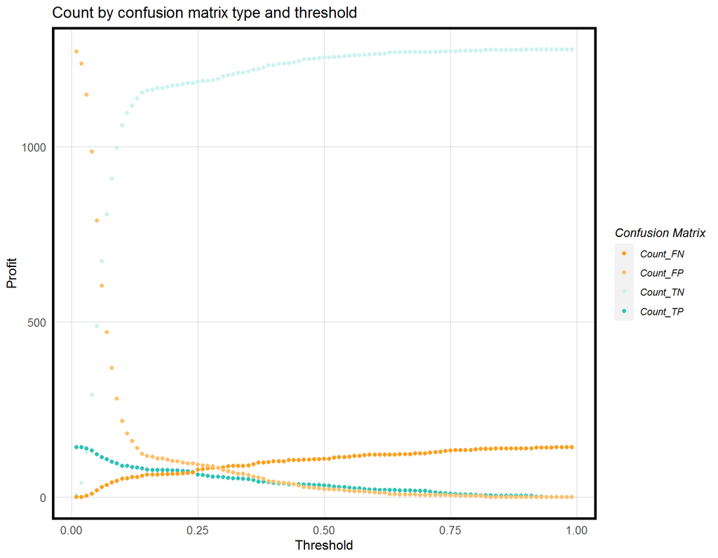

```r
iterateThresholds <- function(data, observedClass, predictedProbs, group) {
#This function takes as its inputs, a data frame with an observed binomial class (1 or 0); a vector of predicted probabilities; and optionally a group indicator like race. It returns accuracy plus counts and rates of confusion matrix outcomes. It's a bit verbose because of the if (missing(group)). I don't know another way to make an optional parameter.
  observedClass <- enquo(observedClass)
  predictedProbs <- enquo(predictedProbs)
  group <- enquo(group)
  x = .01
  all_prediction <- data.frame()

  if (missing(group)) {

    while (x <= 1) {
    this_prediction <- data.frame()

    this_prediction <-
      data %>%
      mutate(predclass = ifelse(!!predictedProbs > x, 1,0)) %>%
      count(predclass, !!observedClass) %>%
      summarize(Count_TN = sum(n[predclass==0 & !!observedClass==0]),
                Count_TP = sum(n[predclass==1 & !!observedClass==1]),
                Count_FN = sum(n[predclass==0 & !!observedClass==1]),
                Count_FP = sum(n[predclass==1 & !!observedClass==0]),
                Rate_TP = Count_TP / (Count_TP + Count_FN),
                Rate_FP = Count_FP / (Count_FP + Count_TN),
                Rate_FN = Count_FN / (Count_FN + Count_TP),
                Rate_TN = Count_TN / (Count_TN + Count_FP),
                Accuracy = (Count_TP + Count_TN) /
                           (Count_TP + Count_TN + Count_FN + Count_FP)) %>%
      mutate(Threshold = round(x,2))

    all_prediction <- rbind(all_prediction,this_prediction)
    x <- x + .01
  }
  return(all_prediction)
  }
  else if (!missing(group)) {
   while (x <= 1) {
    this_prediction <- data.frame()

    this_prediction <-
      data %>%
      mutate(predclass = ifelse(!!predictedProbs > x, 1,0)) %>%
      group_by(!!group) %>%
      count(predclass, !!observedClass) %>%
      summarize(Count_TN = sum(n[predclass==0 & !!observedClass==0]),
                Count_TP = sum(n[predclass==1 & !!observedClass==1]),
                Count_FN = sum(n[predclass==0 & !!observedClass==1]),
                Count_FP = sum(n[predclass==1 & !!observedClass==0]),
                Rate_TP = Count_TP / (Count_TP + Count_FN),
                Rate_FP = Count_FP / (Count_FP + Count_TN),
                Rate_FN = Count_FN / (Count_FN + Count_TP),
                Rate_TN = Count_TN / (Count_TN + Count_FP),
                Accuracy = (Count_TP + Count_TN) /
                           (Count_TP + Count_TN + Count_FN + Count_FP)) %>%
      mutate(Threshold = round(x,2))

    all_prediction <- rbind(all_prediction,this_prediction)
    x <- x + .01
  }
  return(all_prediction)
  }
}

whichThreshold <-
  iterateThresholds(
     data=testProbs, observedClass = Outcome, predictedProbs = Probs)


whichThreshold <-
  whichThreshold %>%
    dplyr::select(starts_with("Count"), Threshold) %>%
    gather(Variable, Count, -Threshold) %>%
    mutate(Revenue =
                 case_when(Variable == "Count_TN"  ~ Count * 0,
                           Variable == "Count_TP"  ~ Count *.25*(66000-7850),
                           Variable == "Count_FN"  ~ Count * 0,
                           Variable == "Count_FP"  ~ Count *(-2850)))

#plot the table
whichThreshold %>%
  ggplot(.,aes(Threshold, Count, colour = Variable)) +
  geom_point() +
  scale_colour_manual(values = palette5) +
  labs(title = "Count by confusion matrix type and threshold",
       y = "Profit") +
  plotTheme() +
  guides(colour=guide_legend(title = "Confusion Matrix"))
```

### 7.2 Revenues by confusion matrix type and threshold

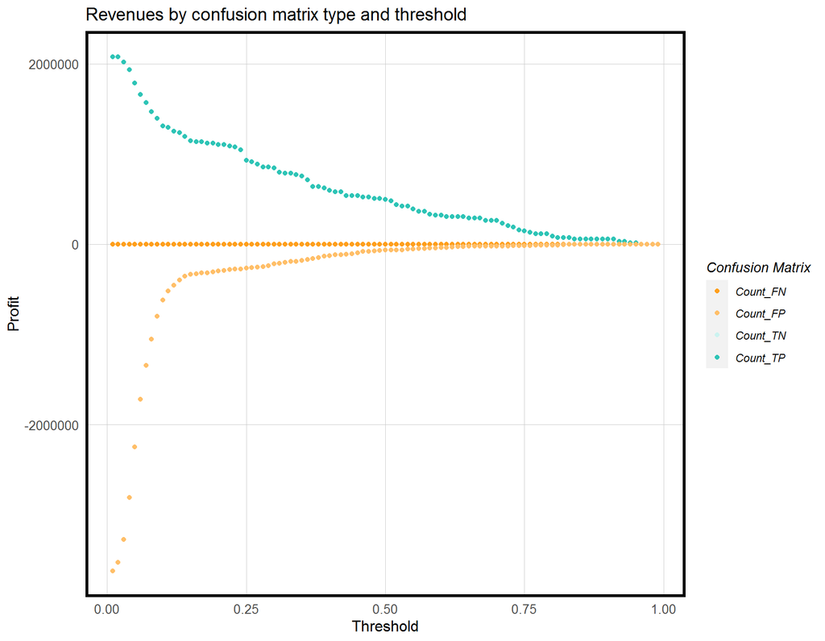

```r
whichThreshold %>%
  ggplot(.,aes(Threshold, Revenue, colour = Variable)) +
  geom_point() +
  scale_colour_manual(values = palette5) +
  labs(title = "Revenues by confusion matrix type and threshold",
       y = "Profit") +
  plotTheme() +
  guides(colour=guide_legend(title = "Confusion Matrix"))
```

### 7.3 Total Revenues By Threshold For Test Sample

The following table demonstrates that when threshold is 0.14, the total revenues are maximum.

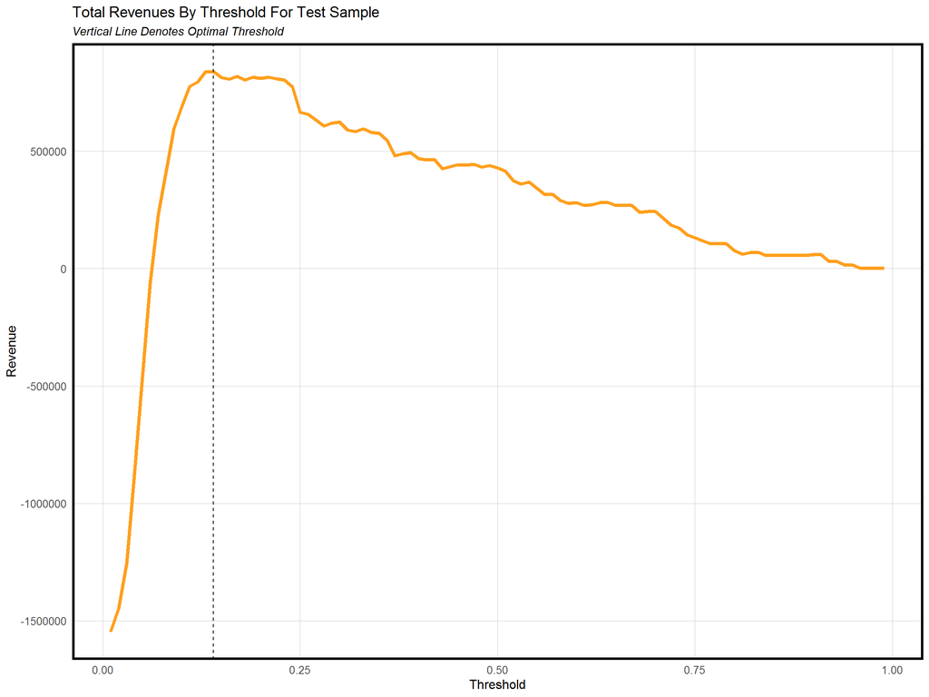

```r
iterateThresholds <- function(data) {
  x = .01
  all_prediction <- data.frame()
  while (x <= 1) {

  this_prediction <-
      testProbs %>%
      mutate(predOutcome = ifelse(Probs > x, 1, 0)) %>%
      count(predOutcome, Outcome) %>%
      summarize(True_Negative = sum(n[predOutcome==0 & Outcome==0]),
                True_Positive = sum(n[predOutcome==1 & Outcome==1]),
                False_Negative = sum(n[predOutcome==0 & Outcome==1]),
                False_Positive = sum(n[predOutcome==1 & Outcome==0])) %>%
     gather(Variable, Count) %>%
     mutate(Revenue =
               ifelse(Variable == "True_Negative", Count * 0,
               ifelse(Variable == "True_Positive", Count *.25*(66000-7850),
               ifelse(Variable == "False_Negative", Count * 0,
               ifelse(Variable == "False_Positive", Count *(-2850), 0)))),
            Threshold = x)

  all_prediction <- rbind(all_prediction, this_prediction)
  x <- x + .01
  }
return(all_prediction)
}

whichThreshold <- iterateThresholds(testProbs)

whichThreshold_revenue <-
whichThreshold %>%
    group_by(Threshold) %>%
    summarize(Revenue = sum(Revenue))

  ggplot(whichThreshold_revenue)+
  geom_line(aes(x = Threshold, y = Revenue),color='#ff9f1c',size = 1.5)+
  plotTheme()+
  geom_vline(xintercept =  pull(arrange(whichThreshold_revenue, -Revenue)[1,1]), linetype=8)+
    labs(title = "Total Revenues By Threshold For Test Sample",
         subtitle = "Vertical Line Denotes Optimal Threshold")
```

### 7.4 Total Count of Credit By Threshold For Test Sample

There could be 2 interpretation of count of credit. In the first interpretation, both of the True-Positive and False-Negative scenarios are taken into account. Given the new targeting algorithm, we assume 25% of contacted eligible homeowners take the credit. However, in this situation we count 100% of False-Negative scenarios by default, which lead to a counter-intuitive outcome that more False-Negative predictions, more credit there will be. However,count of credit in False-Negative scenarios is invalid. In a real marketing process, the credit will not be taken, if the potential houseowners are not contacted based on our prediction result.

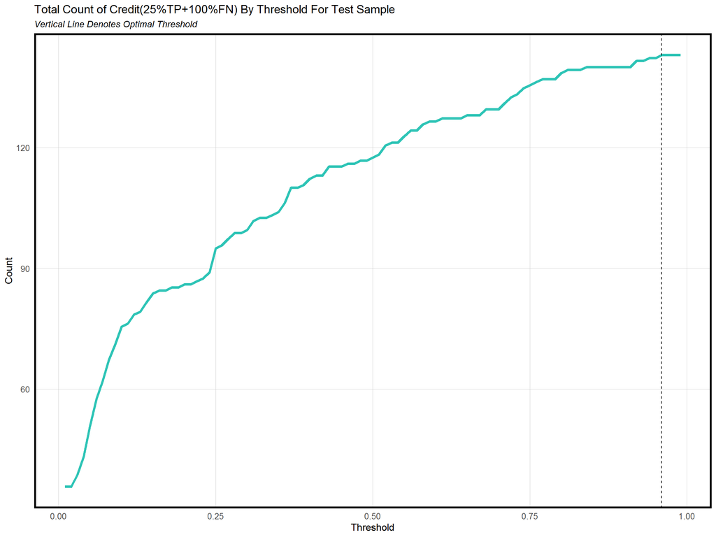

```r
whichThreshold <- iterateThresholds(testProbs)

whichThreshold_count <-
    dplyr::filter(whichThreshold, Variable == "True_Positive"|Variable == "False_Negative") %>%
    mutate(credit =
             ifelse(Variable == "True_Positive", Count * 0.25,
             ifelse(Variable == "False_Negative", Count, 0)))%>%
    group_by(Threshold) %>%
    summarize(Count = sum(credit))

  ggplot(whichThreshold_count)+
  geom_line(aes(x = Threshold, y = Count), color='#2ec4b6',size = 1.5)+
  plotTheme()+
  geom_vline(xintercept =  pull(arrange(whichThreshold_count, -Count)[1,1]),linetype=8)+
    labs(title = "Total Count of Credit(25%TP+100%FN) By Threshold For Test Sample",
         subtitle = "Vertical Line Denotes Optimal Threshold")
```

Therefore, the second interpretation only consider the count of credit generated from True-Positive scenarios. As it is shown, when the threshold is minimum, the count of credit is maximum. Because, when threshold is 0.01, the prediction results are all positive. Accordingly, the count of True-Positive scenarios equal to the actual count of ‘take the credit’.

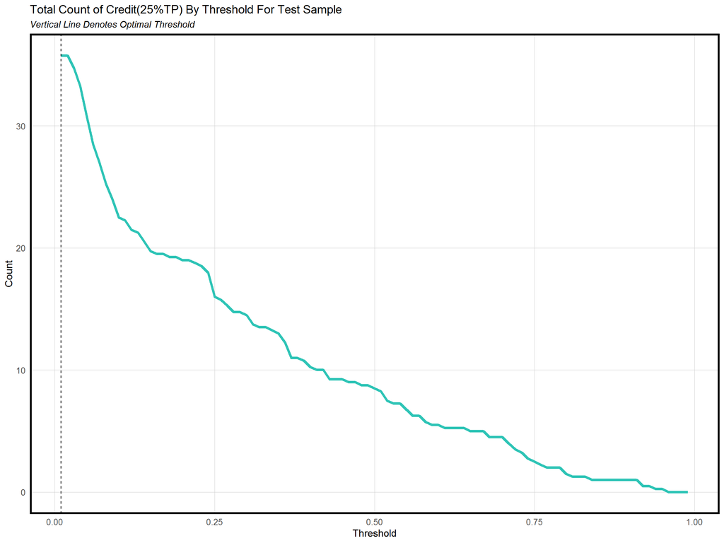

```r
whichThreshold_count <-
    dplyr::filter(whichThreshold, Variable == "True_Positive") %>%
    group_by(Threshold) %>%
    summarize(Count = sum(Count)*.25)

  ggplot(whichThreshold_count)+
  geom_line(aes(x = Threshold, y = Count), color='#2ec4b6',size = 1.5)+
  plotTheme()+
  geom_vline(xintercept =  pull(arrange(whichThreshold_count, -Count)[1,1]),linetype=8)+
    labs(title = "Total Count of Credit(25%TP) By Threshold For Test Sample",
         subtitle = "Vertical Line Denotes Optimal Threshold")
```

Finally, we compare the optimal threshold and the default threshold in the following table. As we can see, the total revenues of optimal threshold are $838,675, which is almost 2 times of the prediction by default threshold. Noticeably, for the reasons discussed before, the total count of credit only take the True-Positive scenarios into account. If we accumulate the count of credits from TP and FN scenarios, the total count of credit of default threshold(0.5) will exceed the that of optimal threshold, which is inconsistent with the predicted revenue.

```r
whichThreshold_sum <-
  whichThreshold %>%
  mutate(credit =
             ifelse(Variable == "True_Positive", round(Count * 0.25),0))%>%
   group_by(Threshold) %>%
    summarize(Total_Revenue = sum(Revenue),
              Total_Count_of_Credits = sum(credit))

optimalThreshold <- pull(arrange(whichThreshold_sum, -Total_Revenue)[1,1])
fiftyPercentThreshold <- 0.5


whichThreshold_table <- subset(whichThreshold_sum, Threshold == as.character(fiftyPercentThreshold) |
                                 Threshold == as.character(optimalThreshold)) %>% kable() %>%
  kable_styling(font_size = 12, full_width = F,
                bootstrap_options = c("striped", "hover", "condensed"))

whichThreshold_table
```

| Threshold | Total_Revenue | Total_Count_of_Credits |
| --- | --- | --- |
| 0.14 | 838675 | 20 |
| 0.50 | 428725 | 8 |

## 8. Conclusion

In conclusion, we will not recommend the model put into production until following issues can be fixed. Firstly, the sensitivity is relatively low. Though series of feature engineering works were conducted, the sensitivity of our prediction results is still at around 0.25. We assume it may result from the sample records where the count of “refuse the credit” is far more than that of “take the credit”. To guarantee a high accuracy in general, the model may “sacrifice” the sensitivity to some extent. Besides, as it is shown in ROC curve, the curve is not as smooth as expected, which indicates overfitting issue may exist. Therefore, our model could be not generalizable enough to other data sets.